# Coursera DSS Capstone Project Milestone Report

Lalit A Patel

29 March 2015

### Introduction

This report summarizes an exploratory analysis of 3 text files. The analysis is meant to prepare for a Next Word Prediction model for the Coursera DSS Capstone Project.

### Part 1: Initial Setup

Coursera-SwiftKey.zip file was downloaded from https://d396qusza40orc.cloudfront.net/dsscapstone/dataset/Coursera-SwiftKey.zip. The zip file was extracted into 4 folders for 4 languages. Each folder contains 3 txt files of blogs, news, and twits.

After experimenting with tm, stringi, and stylo R packages, it was decided to use only common R packages. Part 1 code loads necessary libraries and defines necessary folders. R code chunks in this report can be shown or hidden in a java-enabled Internet browser.

Part 1 R code - Show/Hide

Part 1 took 2 seconds on a dedicated laptop: Intel Core2Duo T6600 2.20GHz, 4GB memory, Windows 8 64bit, RStudio v 0.98.1103.

### Part 2: Data Cleanup and Separation

Each English txt file was read in chunks of 10000 lines. In each chunk: the text was reduced to lower case letters; numbers, punctuations, and stopwords were removed; and the text was broken into separate words. The output was saved for subsequent use, so that this part need not be repeated.

Part 2 R code - Show/Hide

Part 2 took approximately 10 minutes.

### Part 3: Tokenization to 4-grams

Word tokens and n-grams were determined by using a method of adjoining and offsetting vectors. In view of limited computer resources, a sample of chunked files was used for this. A random sequence of the list of chunked files was generated. As many chunked files as possible were processed one by one in the order of this new sequence. In each process: A columnar vector of the separated words was prepared. n copies of this vector were adjoined side by side, Each copy was moved upward by one row compared to its neighbor on the left. Since n-1 rows at top and n-1 rows at bottom do not have all cells, they were removed. The output was saved for subsequent use, so that this part need not be repeated.

Part 3 R code - Show/Hide

Part 3 stopped after processing 60 txt files in about 20 hours.

### Part 4: Computation of Values

Characteristics of files and n-grams were computed as follows.

Part 4 R code - Show/Hide

Part 4 took 714.37 seconds.

|  | Bytes | Characters | Words | Lines | Chunked | Processed |
| --- | --- | --- | --- | --- | --- | --- |
| blogs | 210160014 | 208361438 | 888019 | 899288 | 90 | 21 |
| news | 205811889 | 15683765 | 76987 | 77259 | 8 | 2 |
| twitter | 167105338 | 162384825 | 2358901 | 2360148 | 237 | 37 |

|  | Bytes | nGrams | 0.25Fract | 0.50Fract | 0.75Fract |
| --- | --- | --- | --- | --- | --- |
| Tokens | 7020828 | 295817 | 0.00 | 0.00 | 0.01 |
| 2-grams | 143597681 | 4596186 | 0.02 | 0.17 | 0.58 |
| 3-grams | 287721660 | 7331595 | 0.21 | 0.48 | 0.74 |
| 4-grams | 365331468 | 7630411 | 0.25 | 0.50 | 0.75 |

### Part 5: Visualization by Plots

Plots were prepared for characteristics of files and n-grams, and frequencies of 20 most frequent tokens and n-grams.

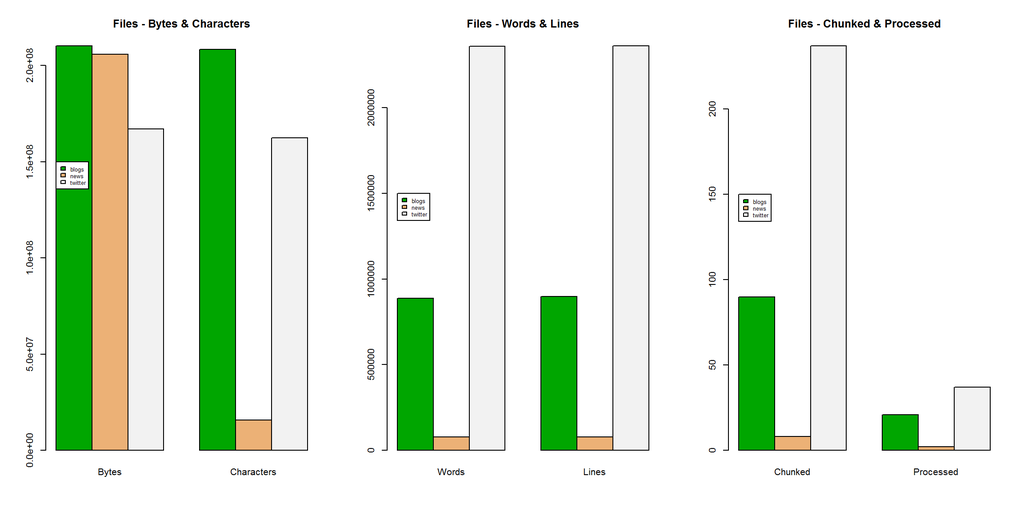

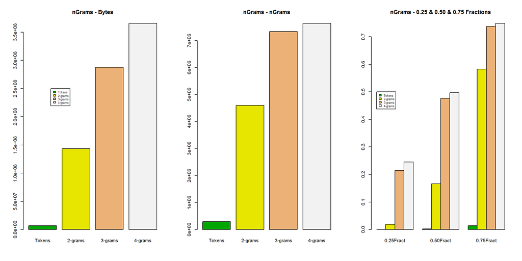

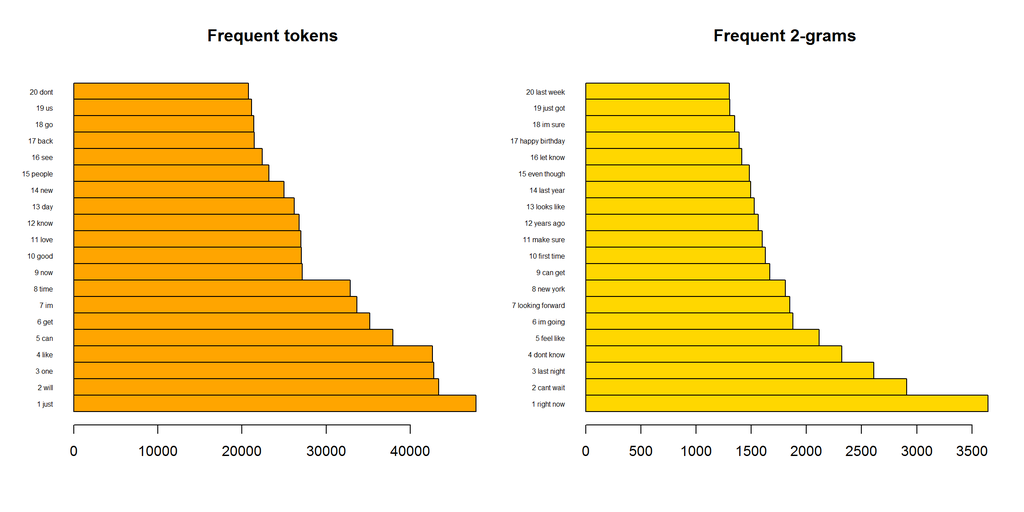

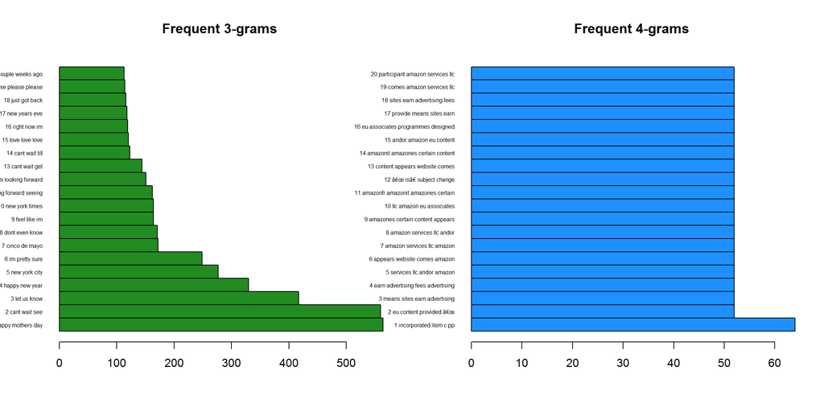

Part 5 took 0.96 seconds.

### Inferences and Conclusion

- Common R packages are sufficient for tokenization, n-grams preparation, and next-word prediction modeling.
- Method of adjoining and offsetting vectors, as used in part 3, is good for determining word tokens and n-grams.
- 4-grams may suffice for a prediction model for this project. Higher n-grams are needed for improving the model.
- A sample of corpora may suffice for n-grams preparation for next-word prediction, due to significant repeatation of n-grams.
- Infrequent n-grams may be removed, since a large part of the content is covered by a few high-frequency n-grams. This can reduce uploading to the sninyapp server and speed up the next-word prediction.
- Part 2 code can be improved to remove foregin words and profanity.
- Part 3 code needs to be improved in speed by making some changes.